# Deep Learning in the Equities Market: A Case Study

## Rise of Quant Investing

If you’ve read anything about investing in the past few years, chances are you have heard about the rise of quantitative hedge funds. Assets run by quant funds have more than doubled in the past decade, rising to a record of $500 billion earlier this year. In some ways, quant investings meteoric rise is due to the same technological advances disrupting many other industries. Faster computers, and more and better data has enabled asset managers to automate skills that were once limited to humans.

[figure not shown]

While the quant investing space is diverse and funds use a variety of methods, one new strategy has been getting a lot of attention: **Deep Learning**. Deep learning is an artifical intelligence technology that loosely mimics the neurons in our brains. Deep learning methodology is employed by what the industry call a **neural network ((NN))**. The technology, which works best with large datasets, already powers Tesla’s self-driving cars and Apple’s Siri voice system.

## What is a Nueral Network, and how to they Help Investors?

Well what the heck is a neural network? Continuing with the brain analogy, neural networks are a computational graph of connected neurons. Neurons exchange signals and connections with one another through math equations, becoming more and more powerful as the system learns. Consider the picture below for a visual representation of how neural network models work.

[figure not shown]

So how can this technology help an investor? Consider an analyst searching for factors that differtiate good and bad stocks. Without deep learning, the analyst must manually select indicators like the price to earnings ratio. With deep learning, the analyst doesn’t have to define the factors in advance, and can feed a NN model with raw company and price data. The artificial nuerons crunch the numbers and adjust their values in order to learn and get closer to the end goal: find factors that differentiate good and bad stocks. s

## Can a Nueral Network help me Make Money?

Deep learning technology might be working for hedge funds, but can it also work for ordinary investors like you or I? In order to find out, I’ve gathered publically available stock data from [Kaggle](https://www.kaggle.com) and created my own neural network model. Like the example above, I give my model information about each stock (PE ratio, accounts receivable, etc.) and the price one year in the future, and the network crunches the numbers and –hopefully– learns to pick good stocks over bad stocks. In total, I provided the model with 76 potential indicators.

Our overall goal is to produce a stock portfolio with a high **Sharpe ratio**. The **Sharpe ratio** characterizes how well the retun of an asset compensates the investor for the risk taken, and is the gold standard metric for evaluating portfolios. For reference, a Sharpe ratio of 1 is considered very good.

Before I reveal the results, I’ll explain how my network creates stock portfolios for the equities market. The first thing we do is split the data into **training**, **validation**, and **testing** sets. The **training set** is used to adjust the weights on the neural network. The **validation set** is data used to make sure the model is not overfitting, or memorizing the training set data. We wan’t our model to generalize, not memorize. The **testing set** is where the action happens. We use the **testing set** to evaluate the predictive power of the neural network model.

After the model is trained, we input the never before seen test data and come up with a set of predictions. If the test data contains data from Apple (AAPL) and General Electric (GE), the model will output price predictions for AAPL and GE stocks.

The next step is to construct a **portfolio**, or combination of stocks to employ our capital. While investors work with a variety of portfolio structures, I’ll try the two most popular: long only and market nuetral (long short). Long only portfolios indicate a net buying stance, and guess that the stocks will rise in price. Market neutral portfolios buy equities that are expected to increase in value and sell short equities that are expected to decrease in value. While both strategies have their merits, many hedge funds use the market neutral approach since it is unexposed to the trends of the broader group of stocks. Market neutral portfolios tend to have lower risk and tend to perform better in economic and financial crisis.

In both cases, I’ll invest in the top 10% of stocks. For long only, I’ll invest equal weight in each stock in the top 10% of predictions. For long short, I’ll invest half my money long in the stocks in the top 5% of predictions, and sell short the stocks in the bottom 5% of predictions.

## Model

Below is a graph that shows important metics during training for two models: one for a market neutral portfolio and another for a long only portfolio.

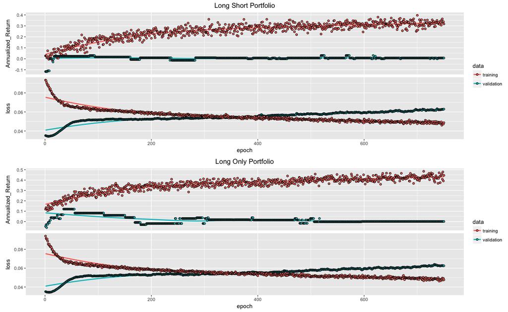

## Choosing a final model

Here’s how it works: Given the full picture of our model throughout training, we select one epoch as the best or optimal model to use on the testing data. There are a variety of ways to do this, and we will take into account both metrics we collect during training, loss and yearly return.

A quick rule of thumb is models that perform well in the validation set tend to be good models.

Now remember, our overal goal is to construct a portfolio with a high **Sharpe ratio**. While neither loss or yearly return are the same as Sharpe ratio, it makes sense that both are correlated with a good portfolio. Loss is the **mean squared error** between our price predictions and the actual prices. It makes sense that having a low mean squared error would be good for a stock portfolio. It also makes sense that a higher return is good for a stock portfolio.

- **Long short portfolio:** As shown on the graph minimum loss value occurs very early in training. Validation annualized return also optimizes very quickly. To counteract those points, I thought the model needed more epochs for training. We will select epoch 300 to construct our final model.
- **Long only portfolio:** Similarly to above, the loss minimizes very quickly. This model features a better shaped annualized return curve and their is a better defined maximum. Even so, I will select epoch 280 to construct the final model.

## Portfolio results

[output not shown]

- **Long only portfolio:** The final model featured an annualied return of 10.38% and an annualied standard deviation of returns of 24.18%, yielding a Sharpe ratio of 0.430.

```
## [1] "long"
```

[output not shown]